# Tochi's Twitter API Data Wrangling Report

[Reference](https://github.com/divyanitin/TwitterDataAnalysis-WeRateDogs/blob/master/wrangle_report.pdf)

### Introduction

This project's objective was to gather WeRateDogs Twitter data in order to produce insightful and reliable analysis and visualizations. This project, which is primarily focused on manipulating data from the WeRateDogs Twitter account using Python and is described in a Jupyter Notebook (OET_twitter_api_project), was a component of the data wrangling phase of the Udacity Data Analyst Nanodegree program.

### Project Description

Real-world data is rarely clean and accurate. I had to gather, assess, and clean the data using Python and its libraries so that the end product can be be used for analysis and visualization. Only a portion of the dataset's issues (no less than eight quality issues and two tidiness issues) required to be fully analyzed and cleaned because doing so would require a lot of work.

The tasks for this project were:

1. Data wrangling, which consisted of:

   • Gathering data

   • Assessing data

   • Cleaning data
2. Storing, analyzing, and visualizing the wrangled data
3. Summarizing my data analysis and visualization findings. (act report.pdf)

### Data Gathering

Three different forms of data were used for this project, and they were acquired as described below:

`1` Twitter Archive File - WeRateDogs: Udacity programmatically extracted this and made twitter archive enhanced.csv available for usage.

`2` Image Predictions File: According to a neural network, each tweet's image predicts the breed of dog that is present. This [url](https://d17h27t6h515a5.cloudfront.net/topher/2017/August/599fd2ad_image-predictions/image-predictions.tsv) used to obtain the file (image predictions.tsv) programmatically from the Udacity's servier.

`3` Twitter API & Tweet JSON File: Using the tweet IDs from the WeRateDogs Twitter archive, I used Python's tweepy module to query the Twitter API for each tweet's JSON data, and I saved the whole set of JSON data for each tweet in a file called tweet_json.txt

### Data Assessment

The three tables were stored and evaluated visually and programmatically after the data had been collected. I searched for dirty data with content problems and messy data with structure problems in both assessments.

Columns "doggo," "floofer," "pupper," and "puppo" in twitter archive enhanced should be a single column named dog_stage, etc. Visual Assessment presented me with concerns such as these.

The majority of the quality concerns that were present in the three datasets were actually revealed when I carried out programmatic assessment. Then I divided the problems into two groups: quality and tidiness, and then splitted the quality concerns into groups based on the datasets and performed consistency, correctness, validity, and completeness checks.

### Data Cleaning

The three data sets that made up this portion of the data wrangling were further broken into the three processes of define, code, and test. To make things simple to grasp, below is a snapshot of the three processes.

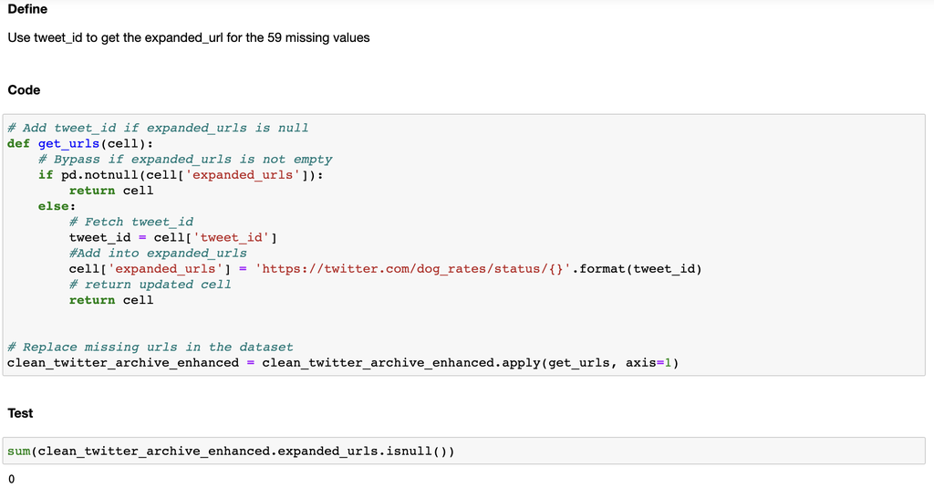

First step was to make duplicates of each of the three data frames. So that rather than using the original frames, I can experiment with the copy frames.

In the image-prediction table, there were rows that obviously weren't about dogs so I dropped them off the dataset. A further assessment of the table showed that the dog names were inconsistent so I corrected that by capitalising the first letters of the dog names in p1, p2, p3 columns using str.title()

Another activity carried out across the 3 datasets was to drop off extraneous columns.

### Data Storage

After I was satisfied with the data cleansing, I realized that combining the three datasets into one final output would make more sense. I combined dog prediction, twitter archive enhanced, and tweeter api to create the twitter_archive_master.csv.

### Project Summary

A skilled data wrangler is able to combine data from many sources, handle common transformation obstacles, and address data quality and cleansing problems. A data wrangler is constantly looking for methods to improve the data and is also very familiar with their data. I accomplished the same using wonderful Python libraries.